# muHVT: Collection of functions used for clustering and construction of hierarchical Voronoi Tessellations for data analysis in R

### Test

Now once we have built the model, let us try to predict using our test dataset which cell and which level each point belongs to.

Let us see predictHVT function.

```r
predictHVT(data,hvt.results,hmap.cols = NULL,child.level = 1,...)
```

Here I will try to explain the important parameters

- **`data`** - A dataframe containing test dataset. The dataframe should have atleast one variable used while training. The variables from this dataset can also be used to overlay as heatmap.
- **`hvt.results`** - A list of hvt.results obtained from HVT function while clustering on train data
- **`hmap.cols`** - The column number of column name from the dataset indicating the variables for which the heat map is to be plotted.(Default = NULL). A heatmap won’t be plotted if NULL is passed
- **`child.level`** -A number indicating the level for which the heat map is to be plotted.(Only used if hmap.cols is not NULL)
- **`...`** - color.vec and line.width can be passed from here

```r
set.seed(420)

predictions <- muHVT::predictHVT(test_computers,hvt.results3,hmap.cols = "price",child.level = 3)
```

The prediction algorithm recursively calculates the distance between each point in the test dataset and the cell centroids for each level. The following steps explain the prediction method for a single point in test dataset :-

1. Calculate the distance between the point and the centroid of all the cells in the first level.
2. Find the cell whose centroid has minimum distance to the point.
3. Check if the cell drills down further to form more cells.
4. If it doesn’t, return the path. Or else repeat the steps 1 to 4 till we reach to the level at which the cell doesn’t drill down further.

Let’s see what cell and which level do each point belongs to. Here I will print first 10 points.

```r
predictions$predictions[1:10,]
```

[output not shown]

### Example Usage 2

In this section, we will see how we can use the package to visualize mutlidimensional data by projecting them to two dimensions using Sammon’s projection.

#### Torus (Donut)

First of all, let us see how to generate data for torus. We are using an amazing library `geozoo` for this purpose. Geo Zoo stands for Geometric Zoo. It is a compilation of geometric objects ranging from three dimensions all the way to the 10 dimension. Geo Zoo contains regular or well-known object, eg cube and sphere, and some abstract objects, eg Boy’s surface, Torus and Hyper-Torus.

Here will generate a 3D torus with 1000 points.

```r
library(geozoo)
library(plotly)

# We will consider only latitude and longitude data.
set.seed(420)

# Here p reprensents dimension of object
# n reperesents number of points

torus <- geozoo::torus(p = 3,n = 1000)
torus_df <- data.frame(torus$points)
colnames(torus_df) <- c("x","y","z")
```

Now let’s do some EDA on the data. First of all, we will see how the data looks like

```r
head(torus_df)
```

[output not shown]

Now let’s have a look at summary and structure of the data.

```r
str(torus_df)
```

```r
summary(torus_df)
```

Now let’s try to visualize the object in 3D Space.

```r
plot_torus <- plot_ly(torus_df, x= ~x, y= ~y, z = ~z, color = ~z) %>% add_markers()
plot_torus
```

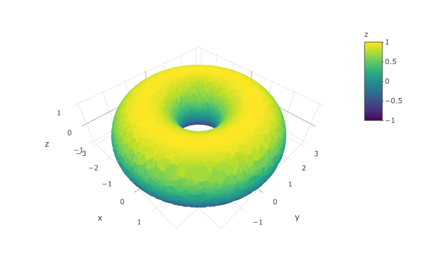

Now let’s try to use the package and project the above 3D geographic object in 2D Space. We will start with number of clusters as 100.

```r
# We will consider only latitude and longitude data.
set.seed(420)

hvt.torus <- muHVT::HVT(torus_df,nclust = 100,depth = 1,quant.err = 0.1,projection.scale = 10,normalize = T)

plotHVT(hvt.torus,line.width = c(1.5,0.8,0.2),color.vec = c("#326273","#ADB2D3","#BFA89E"))
```

[output not shown]

Now let’s repeat the same process with 3D Sphere

#### Sphere

```r
library(geozoo)
library(plotly)

# We will consider only latitude and longitude data.
set.seed(420)

sphere <- geozoo::sphere.hollow()
sphere_df <- data.frame(sphere$points)
colnames(sphere_df) <- c("x","y","z")
```

Let’s get a quick-peek of the data

```r
head(sphere_df)
```

[output not shown]

Now let’s have a look at summary and structure of the data.

```r
str(sphere_df)
```

```r
summary(sphere_df)
```

Now let’s try to visualize the object in 3D Space.

```r
plot_torus <- plot_ly(sphere_df, x= ~x, y= ~y, z = ~z, color = ~z) %>% add_markers()
print(plot_torus)
```

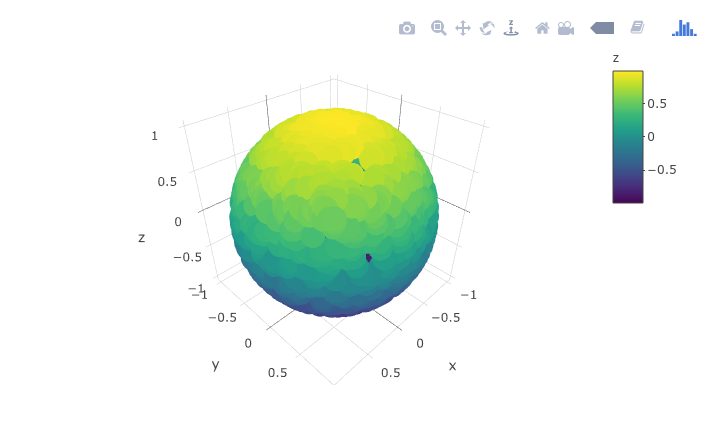

Now let’s try to use the package and project the above 3D geographic object in 2D Space

```r
set.seed(420)

hvt.sphere <- muHVT::HVT(sphere_df,nclust = 100,depth = 1,quant.err = 0.1,projection.scale = 10,normalize = T)

plotHVT(hvt.sphere,line.width = c(1.5,0.8,0.2),color.vec = c("#326273","#ADB2D3","#BFA89E"))
```

[output not shown]

## Applications

1. Pricing Segmentation - The package can be used to discover groups of similar customers based on the customer spend pattern and understand price sensitivity of customers.
2. Market Segmentation - The package can be helpful in market segmentation where we have to cluster micro and macro segments. The method used in this package can do both kinds of segmentation in one go.
3. Anomaly detection - This method can help us categorize system behaviour over time and help us find anomaly when there are changes in the system. For e.g. Finding fraudulent claims in healthcare insurance.
4. The package can help us understand the underlying structure of the data. Suppose that we want to analyze a curved surface such as sphere or vase, we can approximate it by a lot of small low-order polygons in the form of tesselations
5. In biology, Voronoi diagrams are used to model a number of different biological structures, including cells and bone microarchitecture.

# References

1. Vector Quantization : http://www.data-compression.com/vq.html#lbg
2. Hierarchical k-means : http://gecco.org.chemie.uni-frankfurt.de/hkmeans/H-k-means.pdf
3. Sammon’s Projection : http://en.wikipedia.org/wiki/Sammon_mapping
4. Voronoi Tessellations : http://en.wikipedia.org/wiki/Centroidal_Voronoi_tessellation